# Final Assignment: Comparison of US and Russian Discourse on Chechnya

Mariam Mouldin (Khamidova)

##Collecting the data##

1. US - Chechnya

```r
search_urls <- c("https://www.presidency.ucsb.edu/advanced-search?field-keywords=Chechnya&field-keywords2=&field-keywords3=&from%5Bdate%5D=01-01-1999&to%5Bdate%5D=12-31-2002&person2=200298&category2%5B0%5D=&items_per_page=25",
                 "https://www.presidency.ucsb.edu/advanced-search?field-keywords=Chechnya&field-keywords2=&field-keywords3=&from%5Bdate%5D=01-01-1999&to%5Bdate%5D=12-31-2002&person2=200298&category2%5B0%5D=&items_per_page=25&page=1",
                 "https://www.presidency.ucsb.edu/advanced-search?field-keywords=Chechnya&field-keywords2=&field-keywords3=&from%5Bdate%5D=01-01-1999&to%5Bdate%5D=12-31-2002&person2=200298&category2%5B0%5D=&items_per_page=25&page=2")

#the presidency project made it easy to collect the data

get_links_from_page <- function(url) {
  page <- read_html(url)

links <- page %>%
  html_nodes("a") %>%
  html_attr("href") %>%
  str_subset("^/documents/") %>%
  str_subset("guidebook|category-attributes", negate = TRUE) %>%
  unique()

full_links <- paste0("https://www.presidency.ucsb.edu", links)
return(full_links)}

all_links <- map(search_urls, get_links_from_page) %>% unlist() %>% unique()
cat("Found", length(all_links), "documents\n")

scrape_document <- function(url) {
  Sys.sleep(1)
  page <- read_html(url)

  title <- page %>% html_node("h1") %>% html_text(trim = TRUE)
  date <- page %>% html_node(".date-display-single") %>% html_text(trim = TRUE)
  text <- page %>% html_node(".field-docs-content") %>% html_text(trim = TRUE)

  tibble(
    speaker = "Bill Clinton",
    date = date,
    title = title,
    text = text,
    url = url)}

clinton_chechnya_docs <- map_dfr(all_links, scrape_document)
file.rename("us_chechnya_clinton_full.csv", "data/us_chechnya_clinton_full.csv")

clinton_chechnya <- clinton_chechnya_docs %>%
  filter(str_detect(str_to_lower(text), "chechnya|chechen"))
write_csv(clinton_chechnya, "data/us_chechnya_clinton.csv")
print(clinton_chechnya)
```

```r
base_url <- "https://www.presidency.ucsb.edu/advanced-search?field-keywords=Chechnya&field-keywords2=&field-keywords3=&from%5Bdate%5D=01-01-1999&to%5Bdate%5D=12-31-2002&person2=200299&category2%5B%5D=&items_per_page=25"

search_page <- read_html(base_url)

links <- search_page %>%
  html_nodes("a") %>%
  html_attr("href") %>%
  str_subset("^/documents/") %>%
  str_subset("guidebook|category-attributes", negate = TRUE) %>%
  unique()

full_links <- paste0("https://www.presidency.ucsb.edu", links)
print(full_links)

scrape_bush_doc <- function(url) {
  Sys.sleep(1)
  page <- read_html(url)

  title <- page %>% html_node("h1") %>% html_text(trim = TRUE)
  date <- page %>% html_node(".date-display-single") %>% html_text(trim = TRUE)
  text <- page %>% html_node(".field-docs-content") %>% html_text(trim = TRUE)

  tibble(
    speaker = "George W. Bush",
    date = date,
    title = title,
    text = text,
    url = url)}

bush_chechnya_docs <- map_dfr(full_links, scrape_bush_doc)
print(bush_chechnya_docs)
write_csv(bush_chechnya_docs, "data/us_chechnya_bush.csv")
```

```r
archived_urls <- c(
  "https://web.archive.org/web/20010203173100/https://1997-2001.state.gov/statements/1999/991210b.html",
  "https://web.archive.org/web/20010203173300/https://1997-2001.state.gov/statements/1999/991217b.html",
  "https://web.archive.org/web/20010121100800/https://1997-2001.state.gov/statements/2000/000208b.html",
  "https://web.archive.org/web/20010407153633/https://1997-2001.state.gov/statements/2000/000202a.html",
  "https://web.archive.org/web/20010407153856/https://1997-2001.state.gov/statements/2000/000326a.html",
  "https://web.archive.org/web/20010407153444/https://1997-2001.state.gov/statements/1999/991122d.html",
  "https://web.archive.org/web/20010407153533/https://1997-2001.state.gov/statements/1999/991026.html",
  "https://web.archive.org/web/20010407153234/https://1997-2001.state.gov/statements/2000/000102.html",
  "https://web.archive.org/web/20010407153216/https://1997-2001.state.gov/statements/1999/991212.html")

#state.gov didn't allow to scrape, so I had to look for each link on the Wayback Machine

scrape_wayback <- function(url) {
  Sys.sleep(1)

page <- read_html(url)

  if (is.null(page)) return(tibble())

  title <- page %>%
    html_node("title") %>%
    html_text(trim = TRUE)

  text <- page %>%
    html_nodes("p") %>%
    html_text(trim = TRUE) %>%
    paste(collapse = "\n\n")

  date <- str_extract(url, "\\d{8}")

    tibble(
    speaker = "Madeleine Albright",
    date = date,
    title = title,
    text = text,
    url = url)}
albright_archive <- map_dfr(archived_urls, scrape_wayback)
write_csv(albright_archive, "data/us_chechnya_albright_archive.csv")
print(albright_archive)
```

```r
powell_urls <- c(
  "https://web.archive.org/web/20030501010101/https://2001-2009.state.gov/secretary/former/powell/remarks/2003/20665.htm",
  "https://web.archive.org/web/20030601104120/https://2001-2009.state.gov/secretary/former/powell/remarks/36076.htm",
  "https://web.archive.org/web/20020126092813/https://2001-2009.state.gov/secretary/former/powell/remarks/2001/dec/6750.htm",
  "https://web.archive.org/web/20030501010305/https://2001-2009.state.gov/secretary/former/powell/remarks/2003/20571.htm",
  "https://web.archive.org/web/20030709102408/https://2001-2009.state.gov/secretary/former/powell/remarks/2003/17300.htm",
  "https://web.archive.org/web/20030821054856/https://2001-2009.state.gov/secretary/former/powell/remarks/28522.htm",
  "https://web.archive.org/web/20030620041742/https://2001-2009.state.gov/p/eur/rls/rm/2002/10034.htm",
  "https://web.archive.org/web/20020926023852/https://2001-2009.state.gov/secretary/former/powell/remarks/2001/5427.htm",
  "https://web.archive.org/web/20030709101427/https://2001-2009.state.gov/secretary/former/powell/remarks/28163.htm",
  "https://web.archive.org/web/20031203005312/https://2001-2009.state.gov/r/pa/prs/ps/2003/18067.htm",
  "https://web.archive.org/web/20030709101847/https://2001-2009.state.gov/secretary/former/powell/remarks/28495.htm",
  "https://web.archive.org/web/20030709093723/https://2001-2009.state.gov/secretary/former/powell/remarks/35982.htm",
  "https://web.archive.org/web/20020822105245/https://2001-2009.state.gov/secretary/former/powell/remarks/2001/4962.htm",
  "https://web.archive.org/web/20030821055119/https://2001-2009.state.gov/secretary/former/powell/remarks/2003/23836.htm")

scrape_wayback <- function(url) {
  Sys.sleep(1)

page <- tryCatch(
    read_html(GET(url)),
    error = function(e) return(NULL))

  if (is.null(page)) return(tibble())

  title <- page %>%
    html_node("title") %>%
    html_text(trim = TRUE)

  text <- page %>%
    html_nodes("p") %>%
    html_text(trim = TRUE) %>%
    paste(collapse = "\n\n")

  date <- str_extract(url, "\\d{8}")

    tibble(
    speaker = "Colin Powell",
    date = date,
    title = title,
    text = text,
    url = url)}

powell_archive <- map_dfr(powell_urls, scrape_wayback)
write_csv(powell_archive, "data/us_chechnya_powell_archive.csv")
print(powell_archive)
```

```r
clinton <- read_csv("data/us_chechnya_clinton.csv") %>%
  mutate(date = as.character(date))

bush <- read_csv("data/us_chechnya_bush.csv") %>%
  mutate(date = as.character(date))

albright <- read_csv("data/us_chechnya_albright_archive.csv") %>%
  mutate(date = as.character(date))

powell <- read_csv("data/us_chechnya_powell_archive.csv") %>%
  mutate(date = as.character(date))

us_chechnya <- bind_rows(clinton, bush, albright, powell)

write_csv(us_chechnya, "data/us_chechnya.csv")
```

2. Russia - Chechnya

```r
putin_urls <- c(
  "https://web.archive.org/web/20000321000000/https://kremlin.ru/events/president/news/38776",
  "https://web.archive.org/web/20000321010000/https://kremlin.ru/events/president/news/38841",
  "https://web.archive.org/web/20000401000000/https://kremlin.ru/events/president/transcripts/21355",
  "https://web.archive.org/web/20000706000000/https://kremlin.ru/events/president/news/38339",
  "https://web.archive.org/web/20020401000000/https://kremlin.ru/events/president/news/41988",
  "https://web.archive.org/web/20000105000000/https://kremlin.ru/events/president/transcripts/24123",
  "https://web.archive.org/web/20010515090000/https://kremlin.ru/events/president/transcripts/24066",
  "https://web.archive.org/web/20010124120000/https://kremlin.ru/events/president/news/41694",
  "https://web.archive.org/web/20010801083000/https://kremlin.ru/events/president/news/45012",
  "https://web.archive.org/web/20021110120000/https://kremlin.ru/events/president/transcripts/21770",
  "https://web.archive.org/web/20021205080000/https://kremlin.ru/events/president/news/50021",
  "https://web.archive.org/web/20021015000000/https://kremlin.ru/events/president/transcripts/21939",
  "https://web.archive.org/web/20030410070000/https://kremlin.ru/events/president/news/55033",
  "https://web.archive.org/web/20031120090000/https://kremlin.ru/events/president/news/57555",
  "https://web.archive.org/web/20250702051109/http://www.kremlin.ru/events/president/transcripts/24194",
  "https://web.archive.org/web/20250429221314/http://www.kremlin.ru/events/president/transcripts/24197",
  "https://web.archive.org/web/20250627011003/http://www.kremlin.ru/events/president/transcripts/24186",
  "https://web.archive.org/web/20250713085143/http://www.kremlin.ru/events/president/transcripts/24187",
  "https://web.archive.org/web/20241202181833/http://www.kremlin.ru/events/president/news/39010",
  "https://web.archive.org/web/20250425230104/http://www.kremlin.ru/events/president/news/38982",
  "https://web.archive.org/web/20250424102952/http://www.kremlin.ru/events/president/news/39021",
  "https://web.archive.org/web/20161021030321/http://www.kremlin.ru/events/president/news/38998",
  "https://web.archive.org/web/20250522132542/http://www.kremlin.ru/events/president/transcripts/24190",
  "https://web.archive.org/web/20250622221346/http://www.kremlin.ru/events/president/news/37497",
  "https://web.archive.org/web/20250515075452/http://www.kremlin.ru/events/president/transcripts/24066",
  "https://web.archive.org/web/20250617213751/http://www.kremlin.ru/events/president/transcripts/21379",
  "https://web.archive.org/web/20250418203806/http://www.kremlin.ru/events/president/transcripts/24070",
  "https://web.archive.org/web/20250522035152/http://www.kremlin.ru/events/president/transcripts/24129",
  "https://web.archive.org/web/20250418051321/http://www.kremlin.ru/events/president/news/38255",
  "https://web.archive.org/web/20241104222110/http://www.kremlin.ru/events/president/transcripts/24131",
  "https://web.archive.org/web/20241007150023/http://www.kremlin.ru/events/president/news/38252",
  "https://web.archive.org/web/20250210173639/http://www.kremlin.ru/events/president/transcripts/24204",
  "https://web.archive.org/web/20250617102043/http://www.kremlin.ru/events/president/transcripts/24205",
  "https://web.archive.org/web/20250321112955/http://www.kremlin.ru/events/president/transcripts/24214",
  "https://web.archive.org/web/20250615035409/http://www.kremlin.ru/events/president/transcripts/24167",
  "https://web.archive.org/web/20250419193221/http://www.kremlin.ru/events/president/transcripts/21484",
  "https://web.archive.org/web/20250317124321/http://www.kremlin.ru/events/president/transcripts/21480",
  "https://web.archive.org/web/20250321134054/http://www.kremlin.ru/events/president/transcripts/24171",
  "https://web.archive.org/web/20250426222902/http://www.kremlin.ru/events/president/transcripts/21512",
  "https://web.archive.org/web/20250627002315/http://www.kremlin.ru/events/president/transcripts/21558",
  "https://web.archive.org/web/20250424044544/http://www.kremlin.ru/events/president/transcripts/21643",
  "https://web.archive.org/web/20250324133545/http://www.kremlin.ru/events/president/transcripts/21634",
  "https://web.archive.org/web/20250315121848/http://www.kremlin.ru/events/president/news/39422",
  "https://web.archive.org/web/20250320093917/http://www.kremlin.ru/events/president/transcripts/21139",
  "https://web.archive.org/web/20250428013437/http://www.kremlin.ru/events/president/transcripts/21149",
  "https://web.archive.org/web/20250207005501/http://www.kremlin.ru/events/president/transcripts/24352",
  "https://web.archive.org/web/20250524041130/http://www.kremlin.ru/events/president/transcripts/21201",
  "https://web.archive.org/web/20250522140229/http://www.kremlin.ru/events/president/transcripts/24427",
  "https://web.archive.org/web/20250620111519/http://www.kremlin.ru/events/president/transcripts/21207",
  "https://web.archive.org/web/20250320060840/http://www.kremlin.ru/events/president/transcripts/21210",
  "https://web.archive.org/web/20250709004705/http://www.kremlin.ru/events/president/transcripts/21216",
  "https://web.archive.org/web/20250213203336/http://www.kremlin.ru/events/president/transcripts/24399",
  "https://web.archive.org/web/20250318115116/http://www.kremlin.ru/events/president/transcripts/24394",
  "https://web.archive.org/web/20250422221831/http://www.kremlin.ru/events/president/transcripts/21238",
  "https://web.archive.org/web/20250624080550/http://www.kremlin.ru/events/president/transcripts/21269",
  "https://web.archive.org/web/20250406090649/http://www.kremlin.ru/events/president/transcripts/21286",
  "https://web.archive.org/web/20250420075937/http://www.kremlin.ru/events/president/transcripts/21291",
  "https://web.archive.org/web/20250430180048/http://www.kremlin.ru/events/president/transcripts/21315",
  "https://web.archive.org/web/20250113161445/http://www.kremlin.ru/events/president/transcripts/21334",
  "https://web.archive.org/web/20250618232514/http://www.kremlin.ru/events/president/transcripts/21336",
  "https://web.archive.org/web/20250216165527/http://www.kremlin.ru/events/president/transcripts/21335",
  "https://web.archive.org/web/20250428001536/http://www.kremlin.ru/events/president/transcripts/21349",
  "https://web.archive.org/web/20250418110306/http://www.kremlin.ru/events/president/transcripts/21354",
  "https://web.archive.org/web/20250430102610/http://www.kremlin.ru/events/president/transcripts/21394",
  "https://web.archive.org/web/20250207031148/http://www.kremlin.ru/events/president/transcripts/21402",
  "https://web.archive.org/web/20250515184411/http://www.kremlin.ru/events/president/transcripts/21447",
  "https://web.archive.org/web/20250327134737/http://www.kremlin.ru/events/president/transcripts/21456",
  "https://web.archive.org/web/20250419123645/http://www.kremlin.ru/events/president/transcripts/21472",
  "https://web.archive.org/web/20250429010317/http://www.kremlin.ru/events/president/news/26960",
  "https://web.archive.org/web/20250513203019/http://www.kremlin.ru/events/president/transcripts/21515",
  "https://web.archive.org/web/20250623172139/http://www.kremlin.ru/events/president/transcripts/21552",
  "https://web.archive.org/web/20250617211725/http://www.kremlin.ru/events/president/transcripts/24576",
  "https://web.archive.org/web/20250602061358/http://www.kremlin.ru/events/president/transcripts/21565",
  "https://web.archive.org/web/20250619055738/http://www.kremlin.ru/events/president/transcripts/21583",
  "https://web.archive.org/web/20241003235851/http://www.kremlin.ru/events/president/transcripts/21615",
  "https://web.archive.org/web/20250702053723/http://www.kremlin.ru/events/president/transcripts/21651",
  "https://web.archive.org/web/20250516043404/http://www.kremlin.ru/events/president/transcripts/21676",
  "https://web.archive.org/web/20250612195817/http://www.kremlin.ru/events/president/transcripts/21722",
  "https://web.archive.org/web/20250524072606/http://www.kremlin.ru/events/president/transcripts/21770",
  "https://web.archive.org/web/20250523201555/http://www.kremlin.ru/events/president/transcripts/21769",
  "https://web.archive.org/web/20250522112055/http://www.kremlin.ru/events/president/transcripts/21773",
  "https://web.archive.org/web/20250617194922/http://www.kremlin.ru/events/president/transcripts/21774",
  "https://web.archive.org/web/20250615114551/http://www.kremlin.ru/events/president/transcripts/21775",
  "https://web.archive.org/web/20250521183903/http://www.kremlin.ru/events/president/transcripts/21793",
  "https://web.archive.org/web/20250618123216/http://www.kremlin.ru/events/president/transcripts/21818")

#kremlin.ru not only prohibits web scraping, but also restricts document searches to a specific day, so each day had to be checked individually, and then only any related document was looked for on the Wayback Machine

scrape_putin <- function(url) {
  Sys.sleep(1.5)
  page <- tryCatch(read_html(url), error = function(e) NULL)
  if (is.null(page)) return(tibble())

  title <- page %>% html_node("h1") %>% html_text(trim = TRUE)
  text  <- page %>% html_nodes("p") %>% html_text(trim = TRUE) %>% paste(collapse = "\n\n")
  date  <- page %>% html_node("time") %>% html_attr("datetime")
  if (is.na(date)) {
    date <- str_extract(url, "\\d{8}")}

  tibble(
    speaker = "Putin",
    date = date,
    title = title,
    text = text,
    url = url)}

putin_data <- map_dfr(putin_urls, scrape_putin)

putin_chechnya <- putin_data %>%
  filter(str_detect(str_to_lower(text), "chechnya|chechen|чечн(я|ец|цы|ский|ские)?"))

write_csv(putin_chechnya, "data/russia_chechnya_putin.csv")
print(putin_chechnya)
```

```r
putin <- read_csv("data/russia_chechnya_putin.csv") %>%
  mutate(date = as.character(date))

ivanov <- read_csv("data/russia_chechnya_ivanov.csv") %>%
  mutate(date = as.character(date))

#Ivanov file had to be scraped manually, no findings on the Wayback Machine

russia_chechnya <- bind_rows(putin, ivanov)
write_csv(russia_chechnya, "data/russia_chechnya.csv")
```

3. US - Ukraine

```r
search_urls <- c("https://www.presidency.ucsb.edu/advanced-search?field-keywords=Ukraine&field-keywords2=&field-keywords3=&from%5Bdate%5D=02-22-2022&to%5Bdate%5D=01-20-2025&person2=200320&category2%5B%5D=74&category2%5B%5D=68&items_per_page=25",
                 "https://www.presidency.ucsb.edu/advanced-search?field-keywords=Ukraine&field-keywords2=&field-keywords3=&from%5Bdate%5D=02-22-2022&to%5Bdate%5D=01-20-2025&person2=200320&category2%5B0%5D=74&category2%5B1%5D=68&items_per_page=25&page=1",
                 "https://www.presidency.ucsb.edu/advanced-search?field-keywords=Ukraine&field-keywords2=&field-keywords3=&from%5Bdate%5D=02-22-2022&to%5Bdate%5D=01-20-2025&person2=200320&category2%5B0%5D=74&category2%5B1%5D=68&items_per_page=25&page=2",
                 "https://www.presidency.ucsb.edu/advanced-search?field-keywords=Ukraine&field-keywords2=&field-keywords3=&from%5Bdate%5D=02-22-2022&to%5Bdate%5D=01-20-2025&person2=200320&category2%5B0%5D=74&category2%5B1%5D=68&items_per_page=25&page=3",
                 "https://www.presidency.ucsb.edu/advanced-search?field-keywords=Ukraine&field-keywords2=&field-keywords3=&from%5Bdate%5D=02-22-2022&to%5Bdate%5D=01-20-2025&person2=200320&category2%5B0%5D=74&category2%5B1%5D=68&items_per_page=25&page=4",
                 "https://www.presidency.ucsb.edu/advanced-search?field-keywords=Ukraine&field-keywords2=&field-keywords3=&from%5Bdate%5D=02-22-2022&to%5Bdate%5D=01-20-2025&person2=200320&category2%5B0%5D=74&category2%5B1%5D=68&items_per_page=25&page=5",
                 "https://www.presidency.ucsb.edu/advanced-search?field-keywords=Ukraine&field-keywords2=&field-keywords3=&from%5Bdate%5D=02-22-2022&to%5Bdate%5D=01-20-2025&person2=200320&category2%5B0%5D=74&category2%5B1%5D=68&items_per_page=25&page=6")

get_links_from_page <- function(url) {
  page <- read_html(url)

links <- page %>%
  html_nodes("a") %>%
  html_attr("href") %>%
  str_subset("^/documents/") %>%
  str_subset("guidebook|category-attributes", negate = TRUE) %>%
  unique()

full_links <- paste0("https://www.presidency.ucsb.edu", links)
return(full_links)}

all_links <- map(search_urls, get_links_from_page) %>% unlist() %>% unique()
cat("Found", length(all_links), "documents\n")

scrape_document <- function(url) {
  Sys.sleep(1)
  page <- read_html(url)

  title <- page %>% html_node("h1") %>% html_text(trim = TRUE)
  date <- page %>% html_node(".date-display-single") %>% html_text(trim = TRUE)
  text <- page %>% html_node(".field-docs-content") %>% html_text(trim = TRUE)

  tibble(
    speaker = "Joe Biden",
    date = date,
    title = title,
    text = text,
    url = url)}

biden_ukraine_docs <- map_dfr(all_links, scrape_document)
write_csv(biden_ukraine_docs, "data/us_ukraine_biden_docs.csv")

biden_ukraine <- biden_ukraine_docs %>%
  filter(str_detect(str_to_lower(text), "ukrain"))
write_csv(biden_ukraine, "data/us_ukraine_biden.csv")
print(biden_ukraine)
```

```r
blinken_urls <- c(
  "https://web.archive.org/web/20250215064359/https://2021-2025.state.gov/secretary-blinken-and-secretary-austins-travel-to-ukraine/",
  "https://web.archive.org/web/20250214224737/https://2021-2025.state.gov/secretary-blinken-to-deliver-a-speech-on-the-crisis-in-ukraine/",
  "hhttps://web.archive.org/web/20250213154059/https://2021-2025.state.gov/secretary-travel/travel-to-ukraine-and-belgium-september-8-9-2022/",
  "https://web.archive.org/web/20250214041626/https://2021-2025.state.gov/secretary-antony-j-blinken-and-nato-secretary-general-jens-stoltenberg-at-a-joint-press-availability/",
  "https://web.archive.org/web/20250212083710/https://2021-2025.state.gov/secretary-blinken-to-deliver-speech-at-helsinki-city-hall/",
  "https://web.archive.org/web/20250216150059/https://2021-2025.state.gov/secretary-blinkens-remarks-at-the-united-nations-security-council-ministerial-meeting-on-ukraine/",
  "https://web.archive.org/web/20250213011041/https://2021-2025.state.gov/october-10-briefing-with-ambassador-julianne-smith-u-s-permanent-representative-to-the-north-atlantic-treaty-organization-nato/",
  "https://web.archive.org/web/20250212083940/https://2021-2025.state.gov/russias-strategic-failure-and-ukraines-secure-future/",
  "https://web.archive.org/web/20250403171930/https://2021-2025.state.gov/secretary-antony-j-blinken-remarks-to-the-press-31/")

scrape_blinken <- function(url) {
  Sys.sleep(2)

tryCatch({
    page <- read_html(url)

    title <- page %>% html_node("title") %>% html_text(trim = TRUE)

    text <- page %>%
      html_nodes("p") %>%
      html_text(trim = TRUE) %>%
      paste(collapse = "\n\n")

    tibble(
      speaker = "Antony Blinken",
      date = NA_character_,
      title = title,
      text = text,
      url = url)},
    error = function(e) {
    message("Failed on: ", url)
    tibble()})}

blinken_data <- map_dfr(blinken_urls, scrape_blinken)

blinken_ukraine <- blinken_data %>%
  filter(str_detect(str_to_lower(text), "ukrain"))

write_csv(blinken_ukraine, "data/us_ukraine_blinken.csv")
print(blinken_ukraine)
```

```r
trump_urls <- c(
  "https://time.com/7280114/donald-trump-2025-interview-transcript/",
  "https://abcnews.go.com/US/full-transcript-trumps-exclusive-100-days-broadcast-interview/story?id=121291672",
  "https://en.wikisource.org/wiki/Transcript_of_the_2025_Trump–Zelenskyy_meeting",
  "https://abcnews.go.com/Politics/week-transcript-6-8-25-white-house-nec/story?id=123708097",
  "https://transcripts.cnn.com/show/ip/date/2025-01-07/segment/02")

#the Presidency Project contains a vast amount of data even for this 2nd term period, focused here on a few key ones

scrape_trump <- function(url) {
  Sys.sleep(1.5)

  tryCatch({
    page <- read_html(url)
    title <- page %>% html_node("title") %>%
      html_text(trim=TRUE)

    text <- page %>% html_nodes("p") %>%
      html_text(trim=TRUE) %>%
      paste(collapse="\n\n")

    tibble(speaker="Donald Trump", date=NA_character_, title, text, url)},
    error = function(e) {message("Failed:", url); tibble()})}

trump_ukraine <- map_dfr(trump_urls, scrape_trump) %>%
  filter(str_detect(str_to_lower(text), "ukrain"))
write_csv(trump_ukraine, "data/us_ukraine_trump.csv")
head(trump_ukraine)
```

```r
rubio_urls <- c(
"hhttps://web.archive.org/web/20250624041218/https://www.state.gov/secretary-marco-rubio-with-megyn-kelly-of-the-megyn-kelly-show/",
"https://web.archive.org/web/20250407030340/https://www.state.gov/secretary-of-state-marco-rubio-with-george-stephanopoulos-of-abc-this-week/",
"hhttps://web.archive.org/web/20250427175627/ttps://www.state.gov/releases/office-of-the-spokesperson/2025/04/interview-secretary-of-state-marco-rubio-with-kristen-welker-of-nbc-meet-the-press/",
"https://web.archive.org/web/20250428084345/https://www.state.gov/secretary-of-state-marco-rubio-with-kaitlan-collins-of-cnn/",
"https://web.archive.org/web/20250711095736/https://www.state.gov/releases/office-of-the-spokesperson/2025/07/secretary-of-state-marco-rubios-remarks-to-the-press-at-the-kuala-lumpur-convention-center")

scrape_rubio <- function(url) {
  Sys.sleep(1.5)

  tryCatch({
    page <- read_html(url)
    title <- page %>% html_node("title") %>% html_text(trim = TRUE)
    text <- page %>% html_nodes("p") %>% html_text(trim = TRUE) %>% paste(collapse = "\n\n")
    tibble(speaker = "Marco Rubio", date = NA_character_, title, text, url)},
    error = function(e) {
    message("ailed on: ", url)
    tibble()})}

rubio_data <- map_dfr(rubio_urls, scrape_rubio)

rubio_ukraine <- rubio_data %>%
  filter(str_detect(str_to_lower(text), "ukrain"))

write_csv(rubio_ukraine, "data/us_ukraine_rubio.csv")
print(rubio_ukraine)
```

```r
biden <- read_csv("data/us_ukraine_biden.csv") %>%
  mutate(date = as.character(date))

blinken <- read_csv("data/us_ukraine_blinken.csv") %>%
  mutate(date = as.character(date))

trump <- read_csv("data/us_ukraine_trump.csv") %>%
  mutate(date = as.character(date))

rubio <- read_csv("data/us_ukraine_rubio.csv") %>%
  mutate(date = as.character(date))

us_ukraine <- bind_rows(biden, blinken, trump, rubio)
write_csv(us_ukraine, "data/us_ukraine.csv")
```

4. Russia - Ukraine

```r
putin_urls <- c(
  "https://web.archive.org/web/20250418013820/http://kremlin.ru/catalog/countries/UA/events/67825",
  "https://web.archive.org/web/20250514121905/http://kremlin.ru/catalog/countries/UA/events/67828",
  "https://web.archive.org/web/20241207140314/http://kremlin.ru/catalog/countries/UA/events/67843",
  "https://web.archive.org/web/20250520012029/http://kremlin.ru/catalog/countries/UA/events/68254",
  "https://web.archive.org/web/20250622000626/http://kremlin.ru/catalog/countries/UA/events/69390",
  "https://web.archive.org/web/20250425060814/http://kremlin.ru/catalog/countries/UA/events/69568",
  "https://web.archive.org/web/20250626150210/http://kremlin.ru/catalog/countries/UA/events/71256",
  "https://web.archive.org/web/20250612224954/http://kremlin.ru/catalog/countries/UA/events/71329",
  "https://web.archive.org/web/20250420045457/http://kremlin.ru/catalog/countries/UA/events/74856",
  "https://web.archive.org/web/20250428012051/http://kremlin.ru/catalog/countries/UA/events/76446",
  "https://web.archive.org/web/20250522170426/http://kremlin.ru/catalog/countries/UA/events/76600")

scrape_putin <- function(url) {
  Sys.sleep(1.5)

  tryCatch({
    page <- read_html(url)
    title <- page %>% html_node("title") %>% html_text(trim = TRUE)
    text <- page %>% html_nodes("p") %>% html_text(trim = TRUE) %>% paste(collapse = "\n\n")

    tibble(
      speaker = "Vladimir Putin",
      date = NA_character_,
      title = title,
      text = text,
      url = url)},
    error = function(e) {
    message("Failed to scrape: ", url)
    return(tibble(
      speaker = "Vladimir Putin",
      date = NA_character_,
      title = NA_character_,
      text = NA_character_,
      url = url))})}

putin_all <- map_dfr(putin_urls, scrape_putin)

write_csv(putin_all, "putin_raw.csv")

putin_clean <- putin_all %>%
  filter(!is.na(text) & str_trim(text) != "")

keywords_pattern <- "украин|донбас|луганск|днр|лнр|киев|запорож|херсон"

putin_ukraine <- putin_clean %>%
  filter(str_detect(str_to_lower(text), keywords_pattern))

write_csv(putin_ukraine, "data/russia_ukraine_putin.csv")
print(putin_ukraine)
```

```r
lavrov_urls <- c(
  "https://web.archive.org/web/20250313164326/https://mid.ru/ru/foreign_policy/news/2002637",
  "https://web.archive.org/web/20231126213347/https://www.mid.ru/ru/foreign_policy/news/1867466/",
  "https://web.archive.org/web/20230616180311/https://www.mid.ru/ru/foreign_policy/news/1888498/",
  "https://web.archive.org/web/20220709113647/https://www.mid.ru/ru/foreign_policy/news/1821243/",
  "https://web.archive.org/web/20221127042304/https://www.mid.ru/ru/foreign_policy/news/1840230/")

scrape_lavrov <- function(url) {
  Sys.sleep(1.5)

  tryCatch({
    page <- read_html(url)

    title <- page %>%
      html_node("title") %>%
      html_text(trim = TRUE)

    text <- page %>%
      html_nodes("p") %>%
      html_text(trim = TRUE) %>%
      paste(collapse = "\n\n")

    tibble(
      speaker = "Sergey Lavrov",
      date = NA_character_,  # Date parsing could be added later
      title = title,
      text = text,
      url = url)},
    error = function(e) {
    message("Failed to scrape: ", url)
    tibble(
      speaker = "Sergey Lavrov",
      date = NA_character_,
      title = NA_character_,
      text = NA_character_,
      url = url)})}

lavrov_all <- map_dfr(lavrov_urls, scrape_lavrov)

write_csv(lavrov_all, "lavrov_all_raw.csv")

lavrov_clean <- lavrov_all %>%
  filter(!is.na(text) & str_trim(text) != "")

keywords <- "украин|донбас|луганск|днр|лнр|киев|запорож|херсон"

lavrov_ukraine <- lavrov_clean %>%
  filter(str_detect(str_to_lower(text), keywords))

write_csv(lavrov_ukraine, "data/lavrov_ukraine.csv")
print(lavrov_ukraine)
```

```r
scraped <- read_csv("data/lavrov_ukraine.csv", col_types = cols(date = col_character()))
manual <- read_csv("data/lavrov_ukraine_manual.csv", col_types = cols(date = col_character()))

#since I was only able to scrape a limited amount of data, additional information was collected manually

all_cols <- union(colnames(scraped), colnames(manual))

scraped_full <- scraped %>%
  bind_rows(tibble::as_tibble(matrix(NA, nrow = 0, ncol = length(setdiff(all_cols, colnames(scraped))))) %>%
              setNames(setdiff(all_cols, colnames(scraped)))) %>%
  select(all_of(all_cols))

manual_full <- manual %>%
  bind_rows(tibble::as_tibble(matrix(NA, nrow = 0, ncol = length(setdiff(all_cols, colnames(manual))))) %>%
              setNames(setdiff(all_cols, colnames(manual)))) %>%
  select(all_of(all_cols))

lavrov_ukraine_combined <- bind_rows(scraped_full, manual_full)

write_csv(lavrov_ukraine_combined, "data/lavrov_ukraine_combined.csv")
head(lavrov_ukraine_combined)
```

```r
putin <- read_csv("data/russia_ukraine_putin.csv", col_types = cols(date = col_character())) %>%
  mutate(date = as.character(date))

lavrov <- read_csv("data/lavrov_ukraine_combined.csv", col_types = cols(date = col_character())) %>%
  mutate(date = as.character(date))

russia_ukraine <- bind_rows(putin, lavrov)

russia_ukraine <- bind_rows(putin, lavrov)
write_csv(russia_ukraine, "data/russia_ukraine.csv")
```

##Cleaning and tokenizing the data##

```r
us_ukraine <- us_ukraine %>%
  mutate(country = "US", conflict = "Ukraine")

russia_ukraine <- russia_ukraine %>%
  mutate(country = "Russia", conflict = "Ukraine")

us_chechnya <- us_chechnya %>%
  mutate(country = "US", conflict = "Chechnya")

russia_chechnya <- russia_chechnya %>%
  mutate(country = "Russia", conflict = "Chechnya")

df <- bind_rows(us_ukraine, russia_ukraine, us_chechnya, russia_chechnya)

df_counts <- df %>%
  count(country, conflict)

print(df_counts)
```

```
## # A tibble: 4 × 3
##   country conflict     n
##   <chr>   <chr>    <int>
## 1 Russia  Chechnya    45
## 2 Russia  Ukraine     18
## 3 US      Chechnya   111
## 4 US      Ukraine    183
```

*The data collected is highly uneven. However, since the collection process is time-consuming, I will proceed with the current dataset and apply normalization where necessary.*

```r
custom_stopwords <- c(
  stopwords::stopwords("en"),
  stopwords::stopwords("ru"),
  "said", "will", "also", "president", "statement", "government", "people", "chechnya", "ukraine", "russia", "can", "question", "one", "mr", "going", "well", "say", "see", "get", "make", "want", "first", "lockhart", "just", "like", "go", "today", "much", "right", "way", "united", "states", "us", "country", "countries", "years", "states", "world", "new", "time", "last", "many", "two", "think", "putin", "trump", "russian", "iraq", "secretary", "now", "know", "это", "minister", "donald", "come", "powell", "work", "terry", "something", "thank", "things", "moran", "take", "let", "look", "q", "back", "made", "need", "lot", "still", "even", "year","long", "good", "together", "done", "use", "must", "day", "россии", "sure", "saying", "really", "trying", "every", "place", "may", "working", "help", "put", "around", "got", "которые", "continue", "kind", "fact", "never", "since", "ago", "fleischer", "albright", "another", "tell", "talk", "give", "thing", "able", "coming", "clear", "course", "forward", "days", "trade", "questions", "number", "ask",  "украины", "moscow", "whether", "yes", "gouse", "past", "making", "seen", "used", "week", "including", "three", "took", "find", "different", "process", "obviously", "bring", "future", "всё", "hard", "might", "next", "possible", "meet", "prime", "talking", "anything", "happen", "strong", "money", "september", "general", "karl", "answer", "getting", "taken", "months", "taking", "big", "try", "opportunity", "department", "rubio", "always", "asked", "heard", "understand", "matter", "agree", "lavrov", "already", "happened", "talked")

cleaned_tokens <- df %>%
  unnest_tokens(word, text) %>%
  filter(!word %in% custom_stopwords) %>%
  filter(str_detect(word, "^[a-zа-яё']+$"))

cleaned_tokens %>%
  count(word, sort = TRUE) %>%
  print(50)
```

```
## # A tibble: 37,374 × 2
##    word              n
##    <chr>         <int>
##  1 security       1877
##  2 support        1603
##  3 international  1507
##  4 global         1091
##  5 war             997
##  6 cooperation     978
##  7 economic        942
##  8 peace           919
##  9 energy          849
## 10 efforts         829
## # ℹ 37,364 more rows
```

##Analysis and visualization##

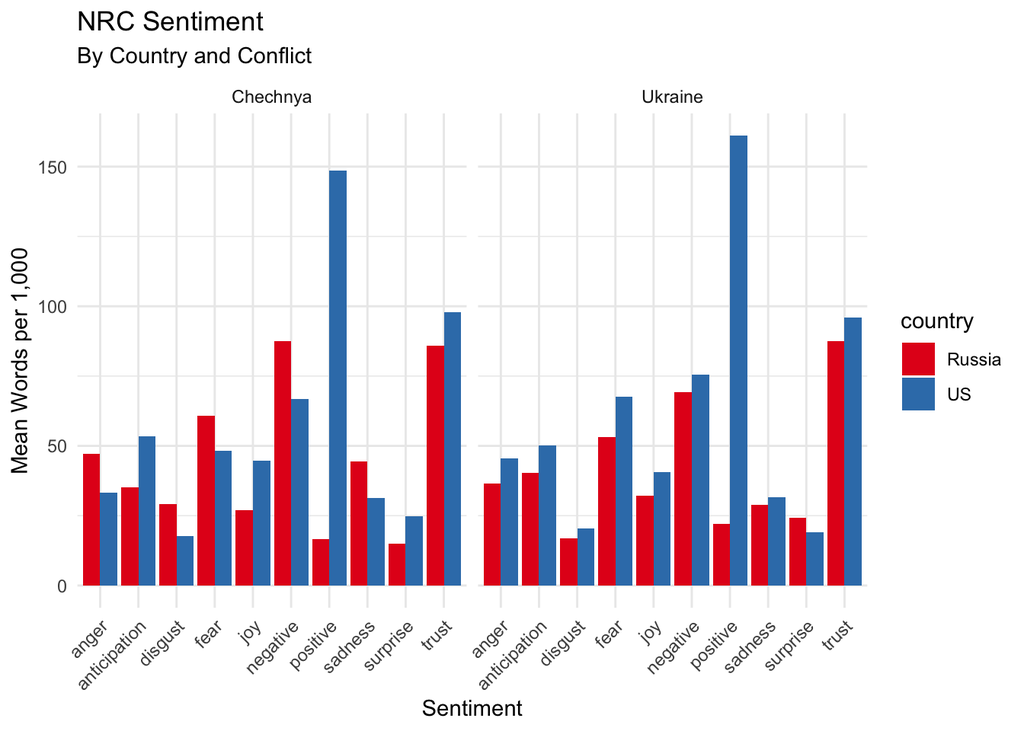

```r
nrc <- get_sentiments("nrc")

#remembered here that sentiment needs to be normalized, since the corpus sizes are imbalanced

total_words_per_doc <- cleaned_tokens %>%
  group_by(speaker, date, title, country, conflict) %>%
  summarise(total_words = n(), .groups = "drop")

sentiment_words_per_doc <- cleaned_tokens %>%
  inner_join(nrc, by = "word") %>%
  group_by(speaker, date, title, country, conflict, sentiment) %>%
  summarise(sentiment_count = n(), .groups = "drop")

normalized_sentiment <- sentiment_words_per_doc %>%
  left_join(total_words_per_doc, by = c("speaker", "date", "title", "country", "conflict")) %>%
  mutate(sentiment_per_1000 = (sentiment_count / total_words) * 1000)

normalized_avg_sentiment <- normalized_sentiment %>%
  group_by(country, conflict, sentiment) %>%
  summarise(avg_sentiment_per_1000 = mean(sentiment_per_1000), .groups = "drop")

nrc_plot <- ggplot(normalized_avg_sentiment, aes(x = sentiment, y = avg_sentiment_per_1000, fill = country)) +
  geom_col(position = "dodge") +
  facet_wrap(~ conflict) +
  theme_minimal() +
  labs(
    title = "NRC Sentiment",
    subtitle = "By Country and Conflict",
    x = "Sentiment",
    y = "Mean Words per 1,000"
  ) +
  scale_fill_brewer(palette = "Set1") +
theme(axis.text.x = element_text(angle = 45, hjust = 1))

nrc_plot
```

```r
ggsave("img/nrc_sentiment_by_country_conflict.png", plot = nrc_plot, dpi = 300)
```

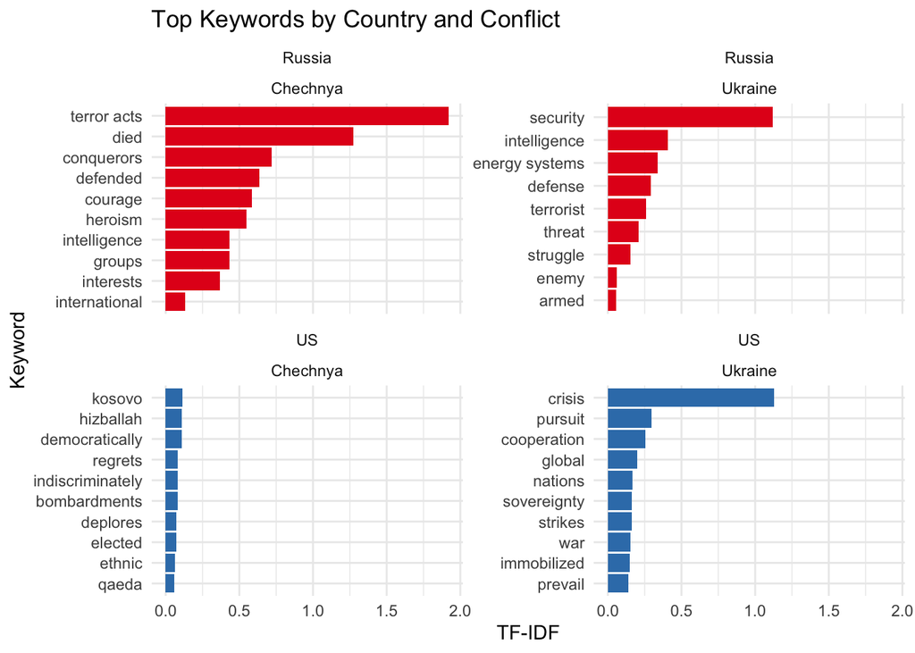

```r
#the output contained many meaningless words, so I realized that further cleaning is necessary

unwanted_words <- c(
  "Lockhart", "lockhart", "gumbel", "atlantik", "парашютно", "vance", "slovakia", "digital", "провел", "магомед", "гудермесе", "докладывать", "доложено", "жителя", "максимальное", "произошедших", "russert", "advertisement","полка", "january", "content", "berger", "сергей", "rice", "germany", "remarks", "заместителю", "провести", "церемонии", "владимиру", "поручил", "путину", "трех", "человека", "прав", "й", "шос", "ташухаджиевых", "цагараев", "woodruff", "yeltsin", "gonna", "чечни", "июня", "ll", "bryant", "archived", "местных", "оказать", "netherlands", "aspen", "bruecke", "cet", "marshall", "грозный", "statedept", "курской", "helsinki", "blinken", "путин", "прибыл", "cards", "sergey", "gov", "websites", "broker", "совещание", "thirty", "семьи", "carlson", "tucker", "schweid", "президента", "кавказе", "северном", "eventsandtravel", "получили", "media", "alright", "eet", "homepage", "youtube", "председатель", "федеральной", "epstein", "выразил", "благодарность", "душанбе", "кардинальные", "комплексное", "комплексные", "окончании", "остановку", "произошли", "северокавказских", "dr", "владимир", "результате", "t", "вручил", "сайди", "цагараева", "современных", "villepin", "coordinated", "loudly", "streamed", "israelis", "austin", "wired", "s", "zelenskyy", "georgian", "федерации", "aartsen", "van", "андрей", "белоусов", "разделе", "чечне", "city", "афганистана", "совета", "тысяч", "председателя", "republic", "spokesperson", "finnish", "hall",  "highlight", "registered", "президент", "ходе", "моздоке", "подчеркнул",  "принимал", "словам", "экономического", "области", "greece", "internet",  "gedda", "priebus", "семье", "shaw",
"bulgaria", "thankful", "biden",  "caucasus", "obama", "designation", "joe", "дел", "используют",  "аэропорту", "бюджетной", "виктору", "властями", "журналистам",  "задолженности", "запланированное", "зарплате", "касьянову", "командным", "машиной", "михаилу", "намерен", "пилота", "полета", "прекративших", "премьерами", "работникам", "селекторное", "су", "управлял", "христенко", "благородную", "брошенный", "выводится", "выполнили", "командир",  "кострому", "лейтенант", "майоров", "месту", "understandings", "groups", "aligned", "maskhadov", "десантно", "постоянными", "вдв", "иванов", "володин", "вайно", "антон", "speech", "inctitute", "est", "notice", "j", "german", "function", "antony", "monitoring", "экологии", "десантного", "природоохранной", "дмитрий", "директор", "валентина", "бортников", "institute", "viewing", "thursday", "press", "office", "online", "fund", "archive", "полк", "медведев", "матвиенко", "лавров", "колокольцев","дополнительные", "updated", "berlin", "tags", "https", "host", "directories", "bureaus", "please", "information", "chilly", "offices", "links", "administrative", "site", "deliver", "edit", "нарышкин", "мишустин", "михаил", "министр", "вячеслав", "александр", "транспорта", "деятельности", "членами", "представитель", "внешней", "contact", "live", "official", "hosted", "пострадавшим", "вывод","содействие","правоохранительного","российской","думы","внутренних","службы","current", "channel","coverage","released","mission","partnership","secure","promises", "вывода", "государственной", "вопросам", "администрации", "бортникову", "белоусову", "андрею", "areas", "edt", "обсудим", "исполняется", "директору", "взаимных", "васильевичу", "co", "pre", "рэмовичу", "рэмовичминистр", "приступим", "исполняются","терактов","гражданскими","амнистии","истребителе","ранения","расследования","вопрос","правительства","иностранных","оборонны","sensitive","history","policy","relations","durable","american","leadership", "новости", "забудут", "взвода", "важный", "борисовичспециальный", "александру", "friday", "travel", "affairs", "видеосвязи", "викторовичпредседатель", "june", "continued", "комментарии", "эдуардовичруководитель",
"supported", "анатольевичзаместитель", "александровичминистр", "васильевичдиректор", "апреля", "владимировичпредседатель", "викторовичминистр", "евгеньевичдиректор", "ивановнапредседатель", "митинг", "направляясь", "вызов", "герой", "десантный", "обсуждению", "договоренности", "прекращением", "justice", "divide", "nato", "osce", "issues", "state", "territory", "strategic", "failure", "подчеркнута", "владимира", "путина", "жак", "ширак", "нато", "важность", "договорённости", "оперативное", "ударов", "mcclellan", "elect", "georgia", "venediktov", "lithuania", "georgia's", "blitzer", "siewert", "council", "polio", "liz", "truss", "tapper", "evan", "hudson", "monastyrskyy", "состоялся", "разговор", "подразделением", "посвященный", "роман", "событию", "заместитель", "провёл", "специальный", "lehrer", "clinton", "leavy", "turkey", "communist", "belie", "muir", "meyers", "pelley", "finland", "torture", "f", "stephanopoulos", "торжественной", "щетнев", "беседы", "обязанности", "самолета", "нужны", "меры", "украиной", "совещании", "nigeria", "bulgarian", "stoyanov", "pritzker", "ransomware", "boak", "kishida", "judy", "pritzker", "italy", "gcc", "дислокации", "звания", "ответили", "проходил", "catalog", "ua", "разделах", "emphasized", "operational", "verified", "giorgia", "meloni", "sweden", "kingdom", "ales", "bialiatski", "ханкале", "государства", "исполняющий", "руководитель", "задать", "приняли", "monitors", "yesterday's", "holding", "holodomor", "referenda", "passover", "nord", "scholz", "loans", "находился", "сообщил", "связанные", "совет", "уважаемые", "коллеги", "добрый", "greek", "sunday's", "enduring", "accountable", "cri", "republicans", "tonight", "героев", "дивизии", "николай", "слово", "поводу", "участие", "россией", "talbott", "range", "friends", "kishida's", "cia", "погибших", "полгода", "день", "хотел", "очень", "прежде", "face", "zakaria", "congratulate", "kyiv's",
"первым", "го", "выступления", "стенограммы", "версия", "года", "bombed", "close", "challenges", "detention", "change", "allies", "объединенной", "сюда", "дата", "доступны", "лицензии", "материал", "impartial", "stream", "материалы", "опубликован", "официальный", "публикации", "thanksgiving", "сайт", "сайта", "ссылка", "текстовая", "conversation", "attribution", "http", "commons", "администрация", "ira", "news", "d", "creative", "ms", "lateral", "bi", "applause", "ways", "взрывов", "open", "год", "задачу", "open", "efforts", "tv", "geneva", "acts", "cycle", "федеральных", "постоянной", "базе", "принял", "главы", "madame", "assets", "events", "prague", "czech", "стал", "пришли", "правительство", "honest", "dutch", "daley", "classrooms", "resolution", "madeleine", "hide", "child", "seemed", "марта", "этому", "военной", "которое", "россия", "сил")

#this was quiet a task

cleaned_tokens <- cleaned_tokens %>%
  filter(!word %in% unwanted_words)

word_counts <- cleaned_tokens %>%
  count(country, conflict, title, word, sort = TRUE)

tfidf_data <- word_counts %>%
  bind_tf_idf(word, title, n)

#forgot the translation part, added later

translation <-c( "терактах" = "terror acts",
  "погибли" = "died",
  "завоеватели" = "conquerors",
  "защитниками" = "defenders",
  "мужество" = "courage",
  "героизм" = "heroism",
  "экстремистами" = "extremist",
  "разведки" = "intelligence",
  "группировки" = "groups",
  "безопасности" = "security",
  "энергосистемам" = "energy systems",
  "обороны" = "defense",
  "террористической" = "terrorist",
  "угрозой" = "threat",
  "борьбе" = "struggle",
  "противника" = "enemy",
  "вооружённых" = "armed",
  "защищали" = "defended",
  "интересы" = "interests",
  "вооружений" = "arms")

top_tfidf <- tfidf_data %>%
  group_by(country, conflict) %>%
  slice_max(tf_idf, n = 10, with_ties = FALSE) %>%
  ungroup()

top_tfidf <- top_tfidf %>%
  mutate(translated_word = if_else(
    word %in% names(translation),
    translation[word],
    word))

tfidf_plot <- top_tfidf %>%
  mutate(translated_word = reorder_within(translated_word, tf_idf, list(country, conflict))) %>%
  ggplot(aes(x = tf_idf, y = translated_word, fill = country)) +
  geom_col(show.legend = FALSE) +
  scale_fill_brewer(palette = "Set1") +
  facet_wrap(country ~ conflict, scales = "free_y") +
  scale_y_reordered() +
  theme_minimal() +
  labs(
    title = "Top Keywords by Country and Conflict",
    x = "TF-IDF", y = "Keyword")

tfidf_plot
```

```r
ggsave("img/tfidf_keywords_by_country_conflict.png", plot = tfidf_plot, dpi = 300, width = 10, height = 7)
```

```r
keyword_map <- tribble(
  ~keyword,        ~country, ~conflict,
  "терактах",      "Russia", "Chechnya",
  "группировки",   "Russia", "Chechnya",
  "безопасности",  "Russia", "Ukraine",
  "угрозой",       "Russia", "Ukraine",
  "freedom",       "US",     "Chechnya",
  "national",      "US",     "Chechnya",
  "islamic",       "US",     "Chechnya",
  "aggression",       "US",     "Ukraine",
  "sovereignty",   "US",     "Ukraine")

keyword_pattern <- str_c("\\b(", str_c(unique(keyword_map$keyword), collapse = "|"), ")\\b")

df_clean <- df %>%
  filter(!is.na(text) & str_trim(text) != "")

sentences_df <- df %>%
  filter(!is.na(text) & str_trim(text) != "") %>%
  mutate(sentence_list = map(text, ~tokenize_sentences(.x)[[1]])) %>%
  unnest(sentence_list) %>%
  rename(sentence = sentence_list) %>%
  mutate(
    sentence_lower = str_to_lower(sentence),
    keyword = str_extract(sentence_lower, regex(keyword_pattern, ignore_case = TRUE))
  ) %>%
  filter(!is.na(keyword))

sentences_filtered <- sentences_df %>%
  semi_join(keyword_map, by = c("keyword", "country", "conflict"))

write_csv(sentences_filtered, "data/keyword_sentences_context.csv")
```

*Interestingly, the US discourse on Chechnya contained the keyword “freedom”, but as the context extraction revealed it is not about advocating for Chechen self-determination or independence, but focusing on individual rights within Russia, such as press freedom and treatment of prisoners. For instance, Bill Clinton’s statement on November 12, 1999 speaks to progress in: “press freedom, democracy, minority rights, and the treatment of prisoners…” This reveals that “freedom” refers to liberal democratic norms inside Russia, not to political freedom or autonomy for Chechnya itself. Clinton’s more direct and powerful remark on November 18, 1999, reveales the limits of US critique: “If they had put you in jail instead of electing you President, I would hope that every leader…would have stood up for you and for freedom in Russia and not said, ‘Well, that is an internal Russian affair…’” drawing a line between internal affairs and international concern: the US will not interfere with Russia’s territorial claims, but will speak out when state power becomes abusive, especially if it violates civil or democratic rights. A key transformation appears in the post-9/11 discourse. In a White House press briefing on September 26, 2001, reporters challenge the sudden shift in the US labeling of Chechen fighters as “terrorists.” The dialogue includes: “All of a sudden, you’re calling them terrorists? … Is this what Putin has asked for, in exchange for his help?” A clear pivot to counterterrorism rhetoric that reflects the US’s new interest in maintaining good relationships with Russia. The US framing of Ukraine suggests that Ukraine’s defense is not just national, it’s existential for the liberal international order. Blinken states: “Everything that we and our allies and partners do… has the same purpose: to help Ukraine defend its sovereignty… and to stand up for the international rules and principles…” This casts Russia’s invasion as a threat not just to Ukraine, but to global order. In stark contrast, Russia’s framing centering on its “security” and perceived threats. In Vladimir Putin’s speech on February 21, 2022, he warns: “Если Россия столкнётся с такой угрозой, как принятие Украины в НАТО… угрозы для нашей страны многократно возрастут.” (If Russia faces such a threat as Ukraine joining NATO, the threats to our country will increase many times over.) Here, Putin flips the narrative: Ukraine’s sovereignty is seen as an existential threat to Russian national security. He further grounds this in international language: “…принцип равной и неделимой безопасности… не укреплять свою безопасность за счёт безопасности других государств.” (The principle of equal and indivisible security… not strengthening one’s security at the expense of others.) Here, Putin uses multilateral language to argue that Western support for Ukraine violates Russia’s right to security, thus reframing the aggressor as the aggrieved. The US response offers a perspective that is different from Russia’s, but also not the same between the two cases themselves, shifting on sovereignty, religious framing, and geopolitical motivations between the two conflicts.*

##Reflection##

Time Window: Chechnya: 1999–2002 (shortened for this assignment) and Ukraine: 2022–present.

Sources:

Russian Narrative: Statements and interviews of President Putin on Chechnya and Ukraine, as well as statements and interviews of Foreign Ministers Igor Ivanov (Chechnya) and Sergey Lavrov (Ukraine). Data was sourced from Kremlin.ru and Mid.ru via the Wayback Machine. Notes: Boris Yeltsin is excluded because Kremlin.ru archives start only from December 31, 1999, with the first document mentioning his stepping down and handing over the presidency to Putin. Igor Ivanov’s data was manually compiled because Mid.ru blocks automated scraping and the Wayback Machine does not have these URLs. Sergey Lavrov’s data was also scraped and collected manually due to restrictions on Mid.ru. Some collected data is in English; some is in Russian.

Translation bias: Russian data was manually translated by the author to preserve rhetorical framing and tone, which could have been lost in automated translation tools.

Corpus Imbalance. The dataset consists of: Chechnya: U.S. discourse: 111 documents Russian discourse: 45 documents Total: 156 Ukraine: U.S. discourse: 183 documents Russian discourse: 18 documents Total: 201 Total corpus size: 357 documents To address imbalances in corpus size, frequencies were normalized per 1,000 words per speech.

Due to time constraints, only a limited amount of data was collected, so any conclusions should be taken with caution.

Data collection posed challenges, especially for Chechnya-related materials dating back over 20 years, which may introduce unintentional selection bias.

This was by far the most challenging assignment I’ve done, and I’m not sure everything went right.

##AI/resources statement

While doing this assignment I consulted the links provided on the CFSS website, the lecture slides available on Canvas, and the relevant sections of the [R for Data Science](https://r4ds.hadley.nz/data-visualize.html#sec-ggplot2-calls). Additionally,I referred many times to ChatGPT for clarification and debugging, especially while scraping.